# Paged HTML Document

Deborah Kapenda

December 2021

### Abstract

This is an abstract. Much can be written here. Uncomment this line to go without an abstract. Abstracts have no spaces, but can have bullets.

Bullets can be created as follows

- You can add bullets, but do not add colons please.
- Line breaks are also not permitted.

# Introduction

References are to be made as follows: (Fama & French, 1997) and Grinold & Kahn (2000) Such authors could also be referenced in brackets (Grinold & Kahn, 2000) and together Grinold & Kahn (2000). Source the reference code from scholar.google.com by clicking on ``cite’’ below article name. Then select BibTeX at the bottom of the Cite window, and proceed to copy and paste this code into your ref.bib file, located in the directory’s Tex folder. Open this file in Rstudio for ease of management, else open it in your preferred Tex environment. Add and manage your article details here for simplicity - once saved, it will self-adjust in your paper.

> I suggest renaming the top line after @article, as done in the template ref.bib file, to something more intuitive for you to remember. Do not change the rest of the code. Also, be mindful of the fact that bib references from google scholar may at times be incorrect. Reference Latex forums for correct bibtex notation.

Writing in Rmarkdown is surprizingly easy - see [this website](https://www.rstudio.com/wp-content/uploads/2015/03/rmarkdown-reference.pdf) cheatsheet for a summary on writing Rmd writing tips.

# Data

Notice how I used the curly brackets and dash to remove the numbering of the data section.

Discussion of data should be thorough with a table of statistics and ideally a figure.

In your tempalte folder, you will find a Data and a Code folder. In order to keep your data files neat, store all of them in your Data folder. Also, I strongly suggest keeping this Rmd file for writing and executing commands, not writing out long pieces of data-wrangling. In the example below, I simply create a ggplot template for scatter plot consistency. I suggest keeping all your data in a data folder.

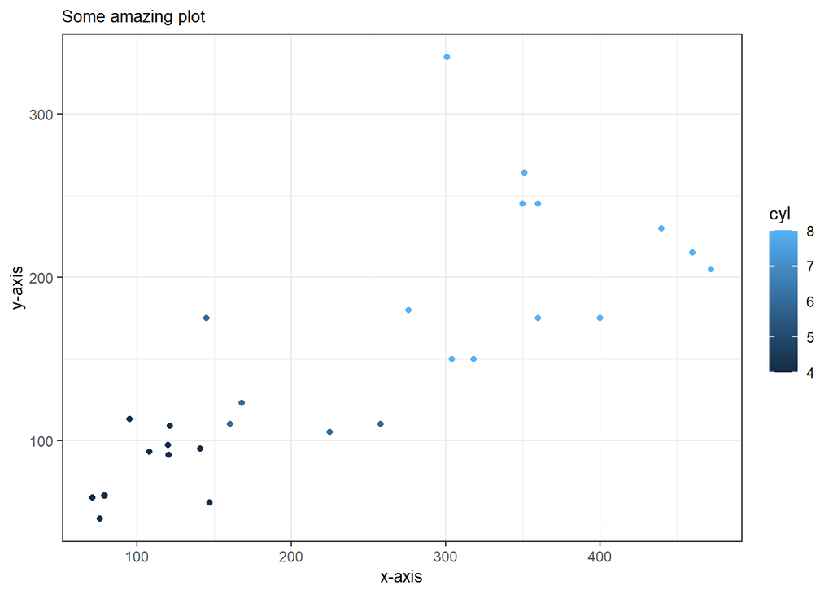

# Methodology

## Subsection

Ideally do not overuse subsections. It equates to bad writing.[^1]

## Math section

Equations should be written as such:

$$\begin{align}
\beta = \sum_{i = 1}^{\infty}\frac{\alpha^2}{\sigma_{t-1}^2} \label{eq1} \\
\int_{x = 1}^{\infty}x_{i} = 1 \notag
\end{align}$$

If you would like to see the equations as you type in Rmarkdown, use $ symbols instead (see this for yourself by adjusted the equation):

$$\beta = \sum_{i = 1}^{\infty}\frac{\alpha^2}{\sigma_{t-1}^2} \\
\int_{x = 1}^{\infty}x_{i} = 1$$

$$\begin{align}
y_t &= c + B(L) y_{t-1} + e_t \label{eq2} \\ \notag
e_t &= H_t^{1/2} z_t ; \quad z_t \sim N(0,I_N) \quad \& \quad H_t = D_tR_tD_t \\ \notag
D_t^2 &= {\sigma_{1,t}, \dots, \sigma_{N,t}} \\ \notag
\sigma_{i,t}^2 &= \gamma_i+\kappa_{i,t} v_{i, t-1}^2 +\eta_i \sigma_{i, t-1}^2, \quad \forall i \\ \notag
R_{t, i, j} &= {diag(Q_{t, i, j}}^{-1}) . Q_{t, i, j} . diag(Q_{t, i, j}^{-1}) \\ \notag
Q_{t, i, j} &= (1-\alpha-\beta) \bar{Q} + \alpha z_t z_t' + \beta Q_{t, i, j} \notag
\end{align}$$

## Results

Tables can be included as follows. Use the *xtable* (or kable) package for tables. Table placement = H implies Latex tries to place the table Here, and not on a new page (there are, however, very many ways to skin this cat. Luckily there are many forums online!).

```r
library(knitr)
library(kableExtra)

data <- mtcars[1:5,] %>% tibble::as_tibble()

table <- kable(data, row.names = TRUE,
      caption = 'Table with kable() and kablestyling()',
      format = "html", booktabs = T) %>%
        kable_styling(full_width = T,
                      latex_options = c("striped",
                                        "scale_down",
                                        "HOLD_position"),
                      font_size = 13)
table
```

Table 1: Table with kable() and kablestyling()

|  | mpg | cyl | disp | hp | drat | wt | qsec | vs | am | gear | carb |
| --- | --- | --- | --- | --- | --- | --- | --- | --- | --- | --- | --- |
| 1 | 21.0 | 6 | 160 | 110 | 3.90 | 2.620 | 16.46 | 0 | 1 | 4 | 4 |
| 2 | 21.0 | 6 | 160 | 110 | 3.90 | 2.875 | 17.02 | 0 | 1 | 4 | 4 |
| 3 | 22.8 | 4 | 108 | 93 | 3.85 | 2.320 | 18.61 | 1 | 1 | 4 | 1 |
| 4 | 21.4 | 6 | 258 | 110 | 3.08 | 3.215 | 19.44 | 1 | 0 | 3 | 1 |
| 5 | 18.7 | 8 | 360 | 175 | 3.15 | 3.440 | 17.02 | 0 | 0 | 3 | 2 |

To reference calculations **in text**, *do this:* From table 1 we see the average value of mpg is 20.98. Notice the use of table-2 in the chunk name. That’s the good stuff.

## 0.1 Model summary

Check [this](https://vincentarelbundock.github.io/modelsummary/articles/modelsummary.html) link out for more. Note this package also plays nicely with gt, kableExtra, etc.

Table 2: Summary: Numeric variables

[output not shown]

<sup>*1*</sup> A very **important** Footnote.

|  | mpg | cyl | disp | hp | drat | wt | qsec | vs | am | gear | carb |
| --- | --- | --- | --- | --- | --- | --- | --- | --- | --- | --- | --- |
| mpg | 1 | . | . | . | . | . | . | . | . | . | . |
| cyl | -.85 | 1 | . | . | . | . | . | . | . | . | . |
| disp | -.85 | .90 | 1 | . | . | . | . | . | . | . | . |
| hp | -.78 | .83 | .79 | 1 | . | . | . | . | . | . | . |
| drat | .68 | -.70 | -.71 | -.45 | 1 | . | . | . | . | . | . |
| wt | -.87 | .78 | .89 | .66 | -.71 | 1 | . | . | . | . | . |
| qsec | .42 | -.59 | -.43 | -.71 | .09 | -.17 | 1 | . | . | . | . |
| vs | .66 | -.81 | -.71 | -.72 | .44 | -.55 | .74 | 1 | . | . | . |
| am | .60 | -.52 | -.59 | -.24 | .71 | -.69 | -.23 | .17 | 1 | . | . |
| gear | .48 | -.49 | -.56 | -.13 | .70 | -.58 | -.21 | .21 | .79 | 1 | . |
| carb | -.55 | .53 | .39 | .75 | -.09 | .43 | -.66 | -.57 | .06 | .27 | 1 |

# References

Fama, E.F. & French, K.R. 1997. Industry costs of equity. *Journal of financial economics*. 43(2):153–193.

Grinold, R.C. & Kahn, R.N. 2000. Active portfolio management.

# Appendix

## Appendix A

Some appendix information here

## Appendix B

[^1]: This is an example of a footnote by the way. Something that should also not be overused.